# Основы вероятностного моделирования угроз

Лабораторная работа № 2

Бердыев Эзиз

1032255390@rudn.ru

Российский университет дружбы народов

2026-09-04

# Информация

## Докладчик

- Бердыев Эзиз
- студент группы НФИмд-01-25
- Российский университет дружбы народов им. П. Лумумбы
- 1032255390@rudn.ru

# Вводная часть

## Актуальность

- Поток атак на сервер — случайный процесс, и планировать защиту по среднему значению недостаточно.
- Практический вопрос звучит иначе: какова вероятность, что нагрузка превысит критический порог?
- Ответ на него определяет запас производительности и пороги срабатывания систем обнаружения атак.

## Объект и предмет исследования

- **Объект** — поток атак на веб-сервер как случайный процесс.
- **Предмет** — пуассоновская модель потока и точность статистической оценки вероятности редкого события.

## Цели и задачи

**Цель** — освоить базовые методы вероятностного моделирования случайных процессов в контексте кибербезопасности.

**Задачи:**

- реализовать модель пуассоновского потока атак;
- проверить соответствие числа атак и интервалов теоретическим законам;
- оценить вероятность события «более 10 атак за час» двумя способами;
- исследовать сходимость оценки при росте объёма выборки;
- выполнить параметрическое исследование по интенсивности.

## Материалы и методы

- Язык Julia [1], пакеты Distributions.jl, StatsPlots.jl;
- DrWatson — структура проекта и именование результатов [2];
- теория пуассоновских процессов [3];
- Literate.jl — литературное программирование.

# Основная часть

## Модель потока

Число атак за интервал $T$:

$$P\{N(T) = k\} = \frac{(\lambda T)^k}{k!}\, e^{-\lambda T} .$$

Интервалы между атаками:

$$f_\tau(x) = \lambda e^{-\lambda x} .$$

Это два эквивалентных описания одного процесса — оба используются в коде.

## Реализация

```julia
function simulate_attacks(λ::Float64, T::Float64)
    hourly_counts = rand(Poisson(λ), floor(Int, T))

    intervals = Float64[]
    total_time = 0.0
    while total_time < T
        τ = rand(Exponential(1 / λ))
        push!(intervals, τ)
        total_time += τ
    end
    total_time > T && pop!(intervals)

    return (hourly_counts = hourly_counts,
            intervals = intervals,
            attack_times = cumsum(intervals))
end
```

## Проверка распределений

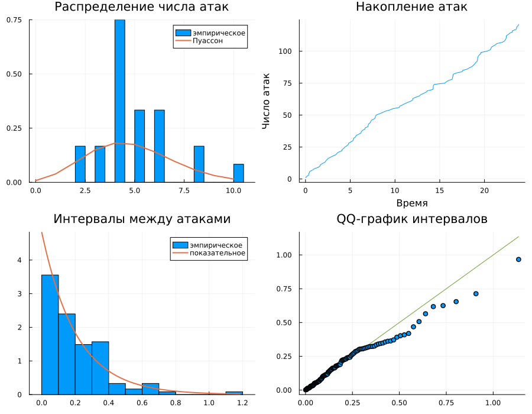

Рис. 1: Распределение числа атак, накопление атак, интервалы и QQ-график

## Оценка вероятности перегрузки

Событие «более 10 атак за час» при $\lambda = 5$:

Табл. 1: Сравнение оценок вероятности

[output not shown]

## Сходимость оценки

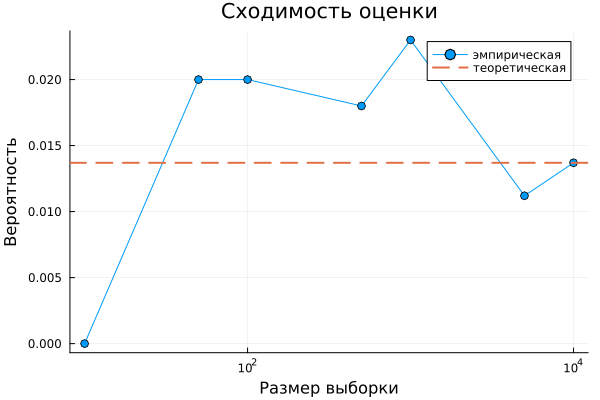

Рис. 2: Сходимость эмпирической оценки к теоретическому значению

При $n = 10^4$ отклонение составило $5 \cdot 10^{-6}$.

## Набор параметров

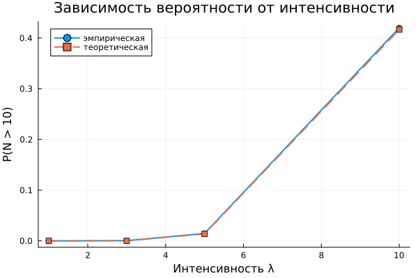

Рис. 3: Зависимость вероятности перегрузки от интенсивности потока

# Результаты

## Полученные результаты

- Модель реализована, результаты сохраняются на диск средствами DrWatson.
- Число атак согласуется с законом Пуассона, интервалы — с показательным законом (гистограммы и QQ-график).
- Вероятность перегрузки оценена двумя способами; расхождение укладывается в случайный разброс.
- Подтверждён закон больших чисел: с ростом $n$ оценка стабилизируется.
- Код преобразован в литературный стиль.

## Главный вывод

- При удвоении интенсивности с 5 до 10 атак/час вероятность перегрузки растёт примерно в 30 раз.
- Зависимость резко нелинейна: запас по производительности, рассчитанный на среднюю нагрузку, перестаёт работать при небольшом росте интенсивности.

## Итоговый слайд

- Цель работы достигнута: методы вероятностного моделирования освоены на практической задаче.
- Модель корректно описывает случайный поток событий.
- Результат применим для обоснования порогов систем обнаружения атак.

## Список литературы

1.

Bezanson J. и др. [Julia: A Fresh Approach to Numerical Computing](https://doi.org/10.1137/141000671) // SIAM Review. 2017. Т. 59, № 1. С. 65–98.

2.

Datseris G. и др. [DrWatson: the perfect sidekick for your scientific inquiries](https://doi.org/10.21105/joss.02673) // Journal of Open Source Software. 2020. Т. 5, № 54. С. 2673.

3.

Kingman J. F. C. Poisson Processes. Oxford: Oxford University Press, 1993. 104 с.